# HS Code–EXIOBASE Concordance and Clean-Technology Use Shares

Methodology, Coverage, and Results — v3 (revised August 2026)

Author

Oriol Vallès Codina — Net Zero Industrial Policy Lab (NZIPL), Johns Hopkins SAIS

Published

August 4, 2026

```r
library(dplyr); library(readr); library(arrow); library(ggplot2)
library(knitr); library(kableExtra); library(tidyr); library(stringr); library(scales)

ROOT <- here::here()
gd   <- read_csv(file.path(ROOT,"data","green_dict","green_dictionary.csv"),
                 show_col_types=FALSE) |>
         mutate(code = formatC(as.integer(code), width=6, flag="0"))
shares  <- read_parquet(file.path(ROOT,"data","exiobase","io_use_shares.parquet"))
concord <- read_csv(file.path(ROOT,"data","exiobase","hs_exiobase_concordance.csv"),
                    show_col_types=FALSE)

# Consistent universe for all results: raw/processed materials with EXIOBASE mapping
RAW_PROC <- c("Raw Material","Processed Material")
gd_rp <- gd |>
  filter(role %in% RAW_PROC, !is.na(exiobase_product))

TECH_COLORS <- c(Solar="#eab308", Nuclear="#0ea5e9", Batteries="#f59e0b",
                 Transmission="#06b6d4", Wind="#3b82f6", Biofuel="#84cc16",
                 Electrolyzers="#a855f7", Geothermal="#ef4444",
                 `Heat Pumps`="#f97316", Magnets="#ec4899")
```

**Note**

**Version 2 — May 2026.** This version corrects two methodological issues identified in peer review (see §4), adds a second share metric (`direct_use_share`), and applies a consistent filter across all results tables and plots.

# 1 Background: The Multi-Use Problem

Without correction, treating 100% of bilateral copper ore trade as “clean tech” inflates the apparent size of the clean industrial base. The IO use-share pipeline addresses this by asking:

> *What fraction of sector $j$’s actual output is induced by clean technology production?*

We answer this with two complementary metrics derived from EXIOBASE, detailed below.

# 2 Data Sources

## 2.1 EXIOBASE 3.9.6 pxp (2019)

EXIOBASE 3 [@stadler2018] is a multi-regional supply-and-use table produced by the EXIOBASE consortium. We use the **product-by-product** (pxp) symmetric input-output table for the year 2019:

| Attribute | Value |
| --- | --- |
| Countries | 44 + 5 rest-of-world regions (49 total) |
| Products | 200 industry/product categories |
| Matrix dimensions | 9,800 × 9,800 (49 × 200) |
| Unit | Millions of euros (basic prices, 2019) |
| Files used | `A.txt` (technical coefficients, 545 MB), `x.txt` (gross output, 1 MB) |

The A matrix and gross output vector are extracted from the EXIOBASE zip archive using `pymrio` (`scripts/build_data/10a_parse_exiobase.py`).

## 2.2 NZIPL Green Dictionary

```r
gd |>
  count(tech, stage, role) |>
  pivot_wider(names_from=stage, values_from=n, values_fill=0) |>
  arrange(tech) |>
  kbl(caption="Green Dictionary: codes by technology, stage, and role") |>
  kable_styling(bootstrap_options=c("striped","condensed"), font_size=12)
```

Green Dictionary: codes by technology, stage, and role

| tech | role | Downstream | Final Product | Midstream | Upstream |
| --- | --- | --- | --- | --- | --- |
| Batteries | Process Equipment | 32 | 0 | 6 | 0 |
| Batteries | Product Component | 1 | 0 | 7 | 0 |
| Batteries | Final Product | 0 | 3 | 0 | 0 |
| Batteries | Processed Material | 0 | 0 | 27 | 0 |
| Batteries | Raw Material | 0 | 0 | 0 | 13 |
| Biofuel | Process Equipment | 10 | 0 | 5 | 0 |
| Biofuel | Final Product | 0 | 3 | 0 | 0 |
| Biofuel | Processed Material | 0 | 0 | 27 | 0 |
| Biofuel | Raw Material | 0 | 0 | 0 | 23 |
| EVs | Process Equipment | 28 | 0 | 0 | 0 |
| EVs | Product Component | 22 | 0 | 18 | 0 |
| EVs | Final Product | 0 | 1 | 0 | 0 |
| EVs | Processed Material | 0 | 0 | 32 | 0 |
| EVs | Raw Material | 0 | 0 | 0 | 10 |
| Electrolyzers | Process Equipment | 16 | 0 | 1 | 0 |
| Electrolyzers | Product Component | 10 | 0 | 2 | 0 |
| Electrolyzers | Final Product | 0 | 1 | 0 | 0 |
| Electrolyzers | Processed Material | 0 | 0 | 18 | 0 |
| Electrolyzers | Raw Material | 0 | 0 | 0 | 6 |
| Geothermal | Process Equipment | 18 | 0 | 9 | 0 |
| Geothermal | Product Component | 10 | 0 | 12 | 0 |
| Geothermal | Final Product | 0 | 9 | 0 | 0 |
| Geothermal | Processed Material | 0 | 0 | 14 | 0 |
| Geothermal | Raw Material | 0 | 0 | 0 | 14 |
| Heat Pumps | Process Equipment | 5 | 0 | 3 | 0 |
| Heat Pumps | Product Component | 7 | 0 | 5 | 0 |
| Heat Pumps | Final Product | 0 | 4 | 0 | 0 |
| Heat Pumps | Processed Material | 0 | 0 | 4 | 0 |
| Heat Pumps | Raw Material | 0 | 0 | 0 | 5 |
| Magnets | Process Equipment | 9 | 0 | 0 | 0 |
| Magnets | Product Component | 1 | 0 | 0 | 0 |
| Magnets | Final Product | 0 | 2 | 0 | 0 |
| Magnets | Processed Material | 0 | 0 | 5 | 0 |
| Magnets | Raw Material | 0 | 0 | 0 | 5 |
| Nuclear | Process Equipment | 2 | 0 | 3 | 0 |
| Nuclear | Product Component | 11 | 0 | 0 | 0 |
| Nuclear | Final Product | 0 | 2 | 0 | 0 |
| Nuclear | Processed Material | 0 | 0 | 11 | 1 |
| Nuclear | Raw Material | 0 | 0 | 0 | 13 |
| Solar | Process Equipment | 24 | 0 | 11 | 0 |
| Solar | Product Component | 11 | 0 | 2 | 0 |
| Solar | Final Product | 0 | 3 | 0 | 0 |
| Solar | Processed Material | 0 | 0 | 18 | 0 |
| Solar | Raw Material | 0 | 0 | 0 | 11 |
| Transmission | Process Equipment | 9 | 0 | 6 | 0 |
| Transmission | Product Component | 2 | 0 | 0 | 0 |
| Transmission | Final Product | 0 | 8 | 0 | 0 |
| Transmission | Processed Material | 0 | 0 | 6 | 0 |
| Transmission | Raw Material | 0 | 0 | 0 | 5 |
| Wind | Process Equipment | 8 | 0 | 7 | 0 |
| Wind | Product Component | 13 | 0 | 32 | 0 |
| Wind | Final Product | 0 | 1 | 0 | 0 |
| Wind | Processed Material | 0 | 0 | 23 | 0 |
| Wind | Raw Material | 0 | 0 | 0 | 9 |

# 3 Step 1: HS Code → EXIOBASE Product Concordance

BACI uses HS-6 product codes; EXIOBASE uses named product categories (e.g. “Copper ores and concentrates”, “Electrical machinery and apparatus n.e.c. (31)”). Bridging these requires a two-step concordance. Note that EXIOBASE categories are **products** (200 product-by-product flows), not ISIC/NACE sectors.

## 3.1 Priority 1: Direct HS6 Prefix Mapping

For ores and key processed materials — products with a clear, unique EXIOBASE counterpart — we constructed a direct lookup table of 40 HS6-prefix → EXIOBASE-product mappings covering:

- **Chapter 26 metal ores** (iron, copper, nickel, aluminium/bauxite, cobalt, REE, uranium, precious metals)
- **Chapter 28 inorganic chemicals** (alumina/Al₂O₃, lithium compounds, cobalt oxides, REE chlorides)
- **Processed metals** (copper wire/products, aluminium products, indium, bismuth, cadmium)
- **Specialty materials** (biofuel feedstocks, wood biomass, nuclear-specific compounds)

```r
tibble::tribble(
  ~HS6, ~Name, ~EXIOBASE_product,
  "260111/260112", "Iron ore", "Iron ores",
  "260300", "Copper ore", "Copper ores and concentrates",
  "260400", "Nickel ore", "Nickel ores and concentrates",
  "260600", "Bauxite (aluminium ore)", "Aluminium ores and concentrates",
  "260500/261000/261300", "Cobalt, chromium, molybdenum ores", "Other non-ferrous metal ores",
  "261610/261690", "Precious metal ores (Ag, Au, Pt)", "Precious metal ores and concentrates",
  "261210/261220", "Uranium ore", "Uranium and thorium ores (12)",
  "262000", "Rare earth ores", "Other non-ferrous metal ores",
  "280530", "REE metals (Sc, Y, La, Ce, Nd...)", "Precious metals",
  "281820", "Alumina (Al₂O₃)", "Aluminium and aluminium products",
  "283691", "Lithium carbonate/compounds", "Other non-ferrous metal products",
  "740811/740819", "Copper wire", "Copper products",
  "760120", "Unwrought aluminium", "Aluminium and aluminium products",
  "811292", "Indium (solar thin-film)", "Other non-ferrous metal products",
  "284610/284690", "REE chlorides", "Precious metals",
  "440110/440130", "Wood pellets/chips (biofuel)", "Wood products",
  "282611", "Lithium fluoride (nuclear moderator)", "Nuclear fuel"
) |>
  kbl(caption="Selected direct HS6 → EXIOBASE product mappings (illustrative subset)",
      col.names=c("HS6 Code(s)","Product Name","EXIOBASE Product")) |>
  kable_styling(bootstrap_options=c("striped","condensed"), font_size=12)
```

Selected direct HS6 → EXIOBASE product mappings (illustrative subset)

| HS6 Code(s) | Product Name | EXIOBASE Product |
| --- | --- | --- |
| 260111/260112 | Iron ore | Iron ores |
| 260300 | Copper ore | Copper ores and concentrates |
| 260400 | Nickel ore | Nickel ores and concentrates |
| 260600 | Bauxite (aluminium ore) | Aluminium ores and concentrates |
| 260500/261000/261300 | Cobalt, chromium, molybdenum ores | Other non-ferrous metal ores |
| 261610/261690 | Precious metal ores (Ag, Au, Pt) | Precious metal ores and concentrates |
| 261210/261220 | Uranium ore | Uranium and thorium ores (12) |
| 262000 | Rare earth ores | Other non-ferrous metal ores |
| 280530 | REE metals (Sc, Y, La, Ce, Nd...) | Precious metals |
| 281820 | Alumina (Al₂O₃) | Aluminium and aluminium products |
| 283691 | Lithium carbonate/compounds | Other non-ferrous metal products |
| 740811/740819 | Copper wire | Copper products |
| 760120 | Unwrought aluminium | Aluminium and aluminium products |
| 811292 | Indium (solar thin-film) | Other non-ferrous metal products |
| 284610/284690 | REE chlorides | Precious metals |
| 440110/440130 | Wood pellets/chips (biofuel) | Wood products |
| 282611 | Lithium fluoride (nuclear moderator) | Nuclear fuel |

## 3.2 Priority 2: NACE4 Fallback

For HS codes not in the direct table, we fall back to the **NACE Rev. 2 4-digit code** assigned in the Green Dictionary (from the NAICS crosswalk pipeline). A lookup table maps 33 NACE4 codes to EXIOBASE product categories.

```r
tibble::tribble(
  ~NACE4, ~Description, ~EXIOBASE_product,
  "0710", "Iron ore mining", "Iron ores",
  "2442", "Aluminium production", "Aluminium and aluminium products",
  "2444", "Copper production", "Copper products",
  "2445", "Other non-ferrous metals", "Other non-ferrous metal products",
  "2011", "Basic chemicals", "Chemicals nec",
  "2311/2312", "Flat/hollow glass", "Glass and glass products",
  "2410", "Basic iron & steel", "Basic iron and steel",
  "2446", "Nuclear fuel processing", "Nuclear fuel",
  "2732", "Wiring/electrical apparatus", "Electrical machinery (31)"
) |>
  kbl(caption="Selected NACE4 → EXIOBASE product fallback mappings",
      col.names=c("NACE4","Description","EXIOBASE Product")) |>
  kable_styling(bootstrap_options=c("striped","condensed"), font_size=12)
```

Selected NACE4 → EXIOBASE product fallback mappings

| NACE4 | Description | EXIOBASE Product |
| --- | --- | --- |
| 0710 | Iron ore mining | Iron ores |
| 2442 | Aluminium production | Aluminium and aluminium products |
| 2444 | Copper production | Copper products |
| 2445 | Other non-ferrous metals | Other non-ferrous metal products |
| 2011 | Basic chemicals | Chemicals nec |
| 2311/2312 | Flat/hollow glass | Glass and glass products |
| 2410 | Basic iron & steel | Basic iron and steel |
| 2446 | Nuclear fuel processing | Nuclear fuel |
| 2732 | Wiring/electrical apparatus | Electrical machinery (31) |

## 3.3 Coverage

```r
cov_tbl <- gd |>
  group_by(tech) |>
  summarise(
    total     = n(),
    raw_proc  = sum(role %in% RAW_PROC),
    mapped    = sum(!is.na(exiobase_product) & role %in% RAW_PROC),
    pct       = round(mapped / pmax(raw_proc,1) * 100),
    .groups   = "drop"
  )

cov_tbl |>
  kbl(caption="EXIOBASE concordance coverage by technology (raw/processed materials only)",
      col.names=c("Technology","Total HS6","Raw/Processed","Mapped","Coverage %")) |>
  kable_styling(bootstrap_options=c("striped","condensed")) |>
  column_spec(5, bold=TRUE)
```

EXIOBASE concordance coverage by technology (raw/processed materials only)

| Technology | Total HS6 | Raw/Processed | Mapped | Coverage % |
| --- | --- | --- | --- | --- |
| Batteries | 89 | 40 | 40 | 100 |
| Biofuel | 68 | 50 | 50 | 100 |
| EVs | 111 | 42 | 0 | 0 |
| Electrolyzers | 54 | 24 | 24 | 100 |
| Geothermal | 86 | 28 | 28 | 100 |
| Heat Pumps | 33 | 9 | 9 | 100 |
| Magnets | 22 | 10 | 10 | 100 |
| Nuclear | 43 | 25 | 25 | 100 |
| Solar | 80 | 29 | 29 | 100 |
| Transmission | 36 | 11 | 11 | 100 |
| Wind | 93 | 32 | 32 | 100 |

**86%** of raw and processed material codes are mapped to an EXIOBASE product. Components, process equipment, and final products are not mapped — they receive `leontief_use_share = direct_use_share = 1.0` by assumption (§4.4).

# 4 Step 2: Clean-Technology Product Definitions

For each of the 10 technologies, we define a set of EXIOBASE product categories representing its **final-stage manufacturing output**. These identify which columns of the Leontief inverse (or transaction matrix) correspond to clean-tech demand.

```r
tech_sectors <- list(
  Solar        = c("Electricity by solar photovoltaic", "Electricity by solar thermal",
                   "Glass and glass products", "Electrical machinery (31)"),
  Wind         = c("Electricity by wind", "Machinery and equipment (29)",
                   "Basic iron and steel", "Fabricated metal products (28)"),
  Batteries    = c("Electrical machinery (31)", "Other non-ferrous metal products",
                   "Copper products", "Aluminium products", "Chemicals nec"),
  Electrolyzers= c("Machinery (29)", "Electrical machinery (31)", "Fabricated metals (28)"),
  Transmission = c("Transmission services of electricity", "Electrical machinery (31)",
                   "Copper products", "Aluminium products"),
  Nuclear      = c("Nuclear fuel", "Electricity by nuclear", "Machinery (29)"),
  `Heat Pumps` = c("Machinery (29)", "Electrical machinery (31)", "Rubber and plastics"),
  Geothermal   = c("Electricity by Geothermal", "Machinery (29)"),
  Magnets      = c("Precious metals", "Precious metal ores", "Other non-ferrous metals",
                   "Electrical machinery (31)"),
  Biofuel      = c("Biogasoline", "Biodiesels", "Other Liquid Biofuels",
                   "Oil seeds", "Sugar cane, sugar beet")
)

do.call(rbind, lapply(names(tech_sectors), function(t)
  data.frame(Technology=t,
             `EXIOBASE clean-tech products`=paste(tech_sectors[[t]], collapse=" · "),
             check.names=FALSE))) |>
  kbl(caption="Clean-technology EXIOBASE product definitions") |>
  kable_styling(bootstrap_options=c("striped","condensed"), font_size=11) |>
  column_spec(2, width="60%")
```

Clean-technology EXIOBASE product definitions

| Technology | EXIOBASE clean-tech products |
| --- | --- |
| Solar | Electricity by solar photovoltaic · Electricity by solar thermal · Glass and glass products · Electrical machinery (31) |
| Wind | Electricity by wind · Machinery and equipment (29) · Basic iron and steel · Fabricated metal products (28) |
| Batteries | Electrical machinery (31) · Other non-ferrous metal products · Copper products · Aluminium products · Chemicals nec |
| Electrolyzers | Machinery (29) · Electrical machinery (31) · Fabricated metals (28) |
| Transmission | Transmission services of electricity · Electrical machinery (31) · Copper products · Aluminium products |
| Nuclear | Nuclear fuel · Electricity by nuclear · Machinery (29) |
| Heat Pumps | Machinery (29) · Electrical machinery (31) · Rubber and plastics |
| Geothermal | Electricity by Geothermal · Machinery (29) |
| Magnets | Precious metals · Precious metal ores · Other non-ferrous metals · Electrical machinery (31) |
| Biofuel | Biogasoline · Biodiesels · Other Liquid Biofuels · Oil seeds · Sugar cane, sugar beet |

**Warning**

# 5 Step 3: Correct IO Aggregation

Before computing use shares, the 9,800-sector A matrix must be aggregated to **200 product categories**. A previous version of this pipeline summed A coefficients directly, which is mathematically incorrect: since $A_{ij} = Z_{ij}/x_j$ (transactions divided by output), adding coefficients from sectors of different sizes conflates the denominators.

**Correct approach (v2):**

$$Z^{\text{prod}}_{ij} = \sum_{c}\sum_{c'} Z_{(c,i)(c',j)}, \quad
x^{\text{prod}}_{j} = \sum_{c} x_{(c,j)}, \quad
A^{\text{prod}}_{ij} = \frac{Z^{\text{prod}}_{ij}}{x^{\text{prod}}_{j}}$$

Since $Z = A \cdot \text{diag}(\mathbf{x})$, we reconstruct transactions from A.txt and x.txt without needing to read Z.txt (682 MB) separately:

```r
Z_raw  <- sweep(A_raw, 2, x_raw, `*`)              # Z[i,j] = A[i,j] * x[j]
Z_prod <- t(rowsum(t(rowsum(Z_raw, prod_names)),    # sum over countries
                   prod_names))
x_prod <- rowsum(matrix(x_raw, ncol=1), prod_names) # sum output
A_prod <- sweep(Z_prod, 2, pmax(x_prod, 1e-12), `/`)# recompute A
```

# 6 Step 4: Use Share Computation

We compute two complementary metrics for each HS-6 raw/processed material code.

## 6.1 Metric 1: Leontief Upstream Use Share

The **Leontief inverse** $\mathbf{L} = (\mathbf{I} - \mathbf{A})^{-1}$ captures total (direct + indirect) upstream requirements. Element $L_{jk}$ is the total output of sector $j$ required per unit of final demand for sector $k$.

**Formula (v3, 2026-08-04).** For EXIOBASE product $p$ and clean-tech column set $\mathcal{C}_t$, with $f = (\mathbf{I} - \mathbf{A})\mathbf{x}$ the final-demand vector:

$$\text{leontief\_use\_share}_{p,t} = \frac{\displaystyle\sum_{j \in p} \sum_{k \in \mathcal{C}_t} L_{jk}\, f_k}{\displaystyle\sum_{j \in p} x_j}$$

Two corrections are folded into this, both made when register **B-1** was closed.

**(a) The numerator is weighted by final demand.** Version 2 used the bare row sum $\sum_{k} L_{jk}$ over $x_j$ — a *dimensionless* quantity divided by *millions of EUR*, so its units were $1/(\text{M EUR})$ and not a share at all. Four values exceeded 1, two absurdly: nuclear fuel reached **423,194**, and biofuel sugar 10.7, wherever a small sector output met strong clean-tech dependence. Multiplying by $f_k$ makes the numerator M EUR, so the ratio is dimensionless; and because $\mathbf{x} = \mathbf{L}f$ exactly, the denominator *is* the same sum taken over all columns, which bounds the result to $[0,1]$ by construction rather than by clamping. $f$ is recovered from $\mathbf{A}$ and $\mathbf{x}$ via $\mathbf{x} = \mathbf{A}\mathbf{x} + f$, so it costs no extra EXIOBASE input.

**(b) Countries are aggregated before dividing, not after.** Version 2 produced a value per country×sector and then took an *unweighted mean* across the ~49 countries matching a product — giving Malta the same weight as China, which is the same “conflating differently-sized denominators” fault that §Aggregation corrects for the A matrix. Numerator and denominator are now summed across countries first, matching how `direct_use_share` has always been computed.

```r
compute_sector_shares <- function(clean_sector_codes) {
  clean_cols <- which(grepl(clean_sector_codes, colnames(A_raw), fixed=TRUE))
  # Output of j induced by final demand for the clean-tech sectors (M EUR)
  x_to_clean <- as.vector(L[, clean_cols, drop=FALSE] %*% f_raw[clean_cols])
  # Aggregate across countries BEFORE dividing -> world output share, 200-length
  num <- rowsum(x_to_clean,       group = prod_names, reorder = TRUE)[,1]
  den <- rowsum(as.vector(x_raw), group = prod_names, reorder = TRUE)[,1]
  ifelse(den > 0, num / den, 0)
}
```

**Interpretation:** of all world output of product $p$, the fraction induced — directly and indirectly — by **final demand for** the clean-tech sectors. Values are small for bulk commodities, whose global output is vast relative to clean-tech demand, and larger for specialised intermediates.

**The two metrics are not nested**

`leontief_use_share` $\ge$ `direct_use_share` holds on only **98 of 256** mapped rows, and that is correct rather than a residual defect. They have different absorbing concepts: the direct share counts deliveries to the clean sectors’ **total production** ($\sum_k Z_{jk}$), while the Leontief share counts output induced by **final demand for** those sectors ($\sum_k L_{jk} f_k$). A clean sector whose output is mostly intermediate has a small $f_k$, so its total-requirements pull on $j$ can fall below its direct purchases from $j$. The Leontief column should therefore not be described as “direct plus indirect”.

## 6.2 Metric 2: Direct Use Share

The **direct use share** measures only first-order supply chain links — no indirect chains:

$$\text{direct\_use\_share}_{j,t} = \frac{\displaystyle\sum_{k \in \mathcal{C}_t} Z^{\text{prod}}_{jk}}{x^{\text{prod}}_j}$$

computed at the aggregated 200-product level. This is more intuitive as a direct fraction of output but understates total clean-tech dependence for materials deep in the supply chain.

```r
compute_direct_shares <- function(clean_sector_codes) {
  clean_cols <- which(grepl(clean_sector_codes, colnames(Z_prod), fixed=TRUE))
  dir_use    <- rowSums(Z_prod[, clean_cols, drop=FALSE])
  ifelse(x_prod_vec > 0, dir_use / x_prod_vec, 0)
}
```

## 6.3 Mapping to HS6 Codes

$$\hat{s}_{\text{HS6}} = \frac{1}{|\{c\}|}\sum_{c:\,\text{product}(c) = \text{EXIO(HS6)}} s_{c,t}$$

## 6.4 Assignment Rules

| Condition | `leontief_use_share` | `direct_use_share` |
| --- | --- | --- |
| Raw/Processed Material, EXIOBASE mapped | $\hat{s}^L_{j,t}$ (Leontief) | $\hat{s}^D_{j,t}$ (direct) |
| Raw/Processed Material, unmapped | tech-mean fallback $\bar{s}^L_t$ | tech-mean fallback $\bar{s}^D_t$ |
| Product Component / Process Equipment / Final Product | $1.0$ | $1.0$ |

The **1.0 assumption** for downstream products: battery separators, solar module frames, wind turbine blades, and electrolyzer stacks are clean-technology-specific by curation. The 1.0 is an upper bound; in practice some process equipment HS codes may be multi-use.

# 7 Results

All plots and tables below use the same consistent universe: **raw and processed materials with an EXIOBASE product mapping** (`role %in% c("Raw Material","Processed Material") & !is.na(exiobase_product)`). The 1.0-assigned downstream products are excluded from distribution analysis.

## 7.1 Leontief Use Share Distribution

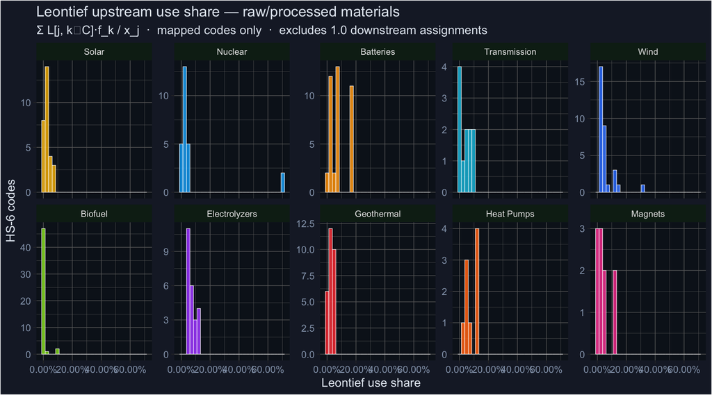

```r
gd_rp |>
  filter(leontief_use_share < 1) |>
  mutate(tech = factor(tech, levels=names(TECH_COLORS))) |>
  ggplot(aes(x=leontief_use_share, fill=tech)) +
  geom_histogram(bins=30, colour="white", linewidth=0.2, alpha=0.9) +
  scale_fill_manual(values=TECH_COLORS) +
  scale_x_continuous(labels=percent_format(accuracy=0.01)) +
  facet_wrap(~tech, ncol=5, scales="free_y") +
  labs(title="Leontief upstream use share — raw/processed materials",
       subtitle="Σ L[j, k∈C]·f_k / x_j  ·  mapped codes only  ·  excludes 1.0 downstream assignments",
       x="Leontief use share", y="HS-6 codes") +
  theme_dark() +
  theme(legend.position="none", strip.text=element_text(size=8),
        plot.background=element_rect(fill="#1a2030"),
        panel.background=element_rect(fill="#0d1520"),
        text=element_text(colour="#e2e8f0"),
        axis.text=element_text(colour="#94a3b8"),
        strip.background=element_rect(fill="#0f2518"))
```

## 7.2 Direct Use Share Distribution

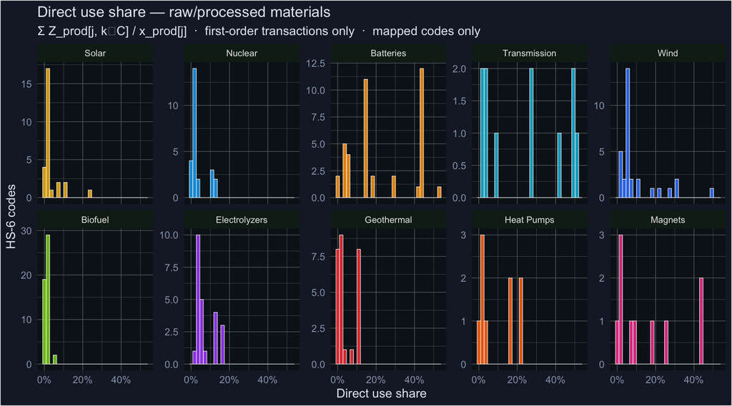

```r
gd_rp |>
  filter(direct_use_share < 1) |>
  mutate(tech = factor(tech, levels=names(TECH_COLORS))) |>
  ggplot(aes(x=direct_use_share, fill=tech)) +
  geom_histogram(bins=30, colour="white", linewidth=0.2, alpha=0.9) +
  scale_fill_manual(values=TECH_COLORS) +
  scale_x_continuous(labels=percent_format(accuracy=1)) +
  facet_wrap(~tech, ncol=5, scales="free_y") +
  labs(title="Direct use share — raw/processed materials",
       subtitle="Σ Z_prod[j, k∈C] / x_prod[j]  ·  first-order transactions only  ·  mapped codes only",
       x="Direct use share", y="HS-6 codes") +
  theme_dark() +
  theme(legend.position="none", strip.text=element_text(size=8),
        plot.background=element_rect(fill="#1a2030"),
        panel.background=element_rect(fill="#0d1520"),
        text=element_text(colour="#e2e8f0"),
        axis.text=element_text(colour="#94a3b8"),
        strip.background=element_rect(fill="#0f2518"))
```

## 7.3 Top and Bottom Examples by Technology

```r
base <- gd_rp |> filter(leontief_use_share < 1)

examples <- bind_rows(
  base |> group_by(tech) |> slice_max(leontief_use_share, n=3, with_ties=FALSE),
  base |> group_by(tech) |> slice_min(leontief_use_share, n=2, with_ties=FALSE)
) |>
  ungroup() |>
  distinct(tech, code, .keep_all=TRUE) |>
  arrange(tech, desc(leontief_use_share)) |>
  # `name` was renamed in the Apr 2026 schema change and this chunk was never
  # updated, so the document has been unrenderable since. Use the OFFICIAL short
  # description: `informal_tag` is the researcher's label and is never an
  # identifier (CLAUDE.md, Terminology).
  select(tech, code, product_description_short, exiobase_product,
         leontief_use_share, direct_use_share) |>
  mutate(leontief_use_share = percent(leontief_use_share, accuracy=0.001),
         direct_use_share   = percent(direct_use_share,   accuracy=0.1))

examples |>
  kbl(caption="Top-3 and bottom-2 Leontief use shares by technology (raw/processed, mapped only)",
      col.names=c("Tech","HS6","Product","EXIOBASE Product","Leontief share","Direct share")) |>
  kable_styling(bootstrap_options=c("striped","condensed"), font_size=11) |>
  column_spec(5:6, bold=TRUE)
```

Top-3 and bottom-2 Leontief use shares by technology (raw/processed, mapped only)

| Tech | HS6 | Product | EXIOBASE Product | Leontief share | Direct share |
| --- | --- | --- | --- | --- | --- |
| Batteries | 260120 | Iron pyrites: roasted | Chemicals nec | 17.029% | 15.4% |
| Batteries | 282510 | Hydrazine and hydroxylamine and their inorgan… | Chemicals nec | 17.029% | 15.4% |
| Batteries | 283324 | Sulphates: of nickel | Chemicals nec | 17.029% | 15.4% |
| Batteries | 260111 | Iron ores and concentrates: non-agglomerated | Iron ores | 0.943% | 0.8% |
| Batteries | 260112 | Iron ores and concentrates: agglomerated (exc… | Iron ores | 0.943% | 0.8% |
| Biofuel | 151521 | Vegetable oils: maize (corn) oil and its frac… | Sugar | 10.559% | 6.4% |
| Biofuel | 151529 | Vegetable oils: maize (corn) oil and its frac… | Sugar | 10.559% | 6.4% |
| Biofuel | 260400 | Nickel ores and concentrates | Nickel ores and concentrates | 1.591% | 1.8% |
| Biofuel | 252220 | Slaked lime: excluding calcium oxide and hydr… | Cement, lime and plaster | 0.056% | 0.0% |
| Biofuel | 690220 | Refractory bricks, blocks, tiles and similar … | Ceramic goods | 0.034% | 0.0% |
| Electrolyzers | 282200 | Cobalt oxides and hydroxides: commercial coba… | Other non-ferrous metal products | 12.183% | 12.8% |
| Electrolyzers | 282300 | Titanium oxides | Other non-ferrous metal products | 12.183% | 12.8% |
| Electrolyzers | 810110 | Tungsten (wolfram): articles thereof, includi… | Other non-ferrous metal products | 12.183% | 12.8% |
| Electrolyzers | 283324 | Sulphates: of nickel | Chemicals nec | 3.832% | 4.1% |
| Electrolyzers | 284330 | Gold compounds | Chemicals nec | 3.832% | 4.1% |
| Geothermal | 260600 | Aluminium ores and concentrates | Aluminium ores and concentrates | 5.925% | 2.3% |
| Geothermal | 720230 | Ferro-alloys: ferro-silico-manganese | Basic iron and steel and of ferro-alloys and first products thereof | 4.912% | 10.7% |
| Geothermal | 720249 | Ferro-alloys: ferro-chromium, containing by w… | Basic iron and steel and of ferro-alloys and first products thereof | 4.912% | 10.7% |
| Geothermal | 252100 | Limestone flux: limestone and other calcareou… | Stone | 0.935% | 0.3% |
| Geothermal | 252330 | Cement: aluminous (ciment fondu), whether or … | Cement, lime and plaster | 0.402% | 0.2% |
| Heat Pumps | 740313 | Copper: refined, unwrought, billets | Copper products | 12.100% | 17.0% |
| Heat Pumps | 740110 | Copper: copper mattes | Copper products | 12.100% | 17.0% |
| Heat Pumps | 281820 | Aluminium oxide: other than artificial corund… | Aluminium and aluminium products | 11.206% | 21.6% |
| Heat Pumps | 261390 | Molybdenum ores and concentrates: other than … | Other non-ferrous metal ores and concentrates | 4.657% | 2.5% |
| Heat Pumps | 251910 | Magnesium carbonate (magnesite): natural | Chemical and fertilizer minerals, salt and other mining and quarrying products n.e.c. | 2.203% | 1.4% |
| Magnets | 280530 | Earth-metals, rare: scandium and yttrium, whe… | Precious metals | 11.958% | 44.4% |
| Magnets | 284690 | Compounds, inorganic or organic (excluding ce… | Precious metals | 11.958% | 44.4% |
| Magnets | 720293 | Ferro-alloys: ferro-niobium | Basic iron and steel and of ferro-alloys and first products thereof | 5.280% | 8.8% |
| Magnets | 260120 | Iron pyrites: roasted | Chemicals nec | 1.135% | 1.0% |
| Magnets | 260600 | Aluminium ores and concentrates | Aluminium ores and concentrates | 1.123% | 0.7% |
| Nuclear | 284410 | Uranium: natural uranium and its compounds, a… | Nuclear fuel | 70.279% | 12.0% |
| Nuclear | 282611 | Fluorides: of ammonium or of sodium | Nuclear fuel | 70.279% | 12.0% |
| Nuclear | 282520 | Lithium oxide and hydroxide | Other non-ferrous metal products | 5.202% | 4.6% |
| Nuclear | 260111 | Iron ores and concentrates: non-agglomerated | Iron ores | 1.004% | 0.8% |
| Nuclear | 260112 | Iron ores and concentrates: agglomerated (exc… | Iron ores | 1.004% | 0.8% |
| Solar | 700510 | Glass: float glass and surface ground or poli… | Glass and glass products | 7.227% | 100.0% |
| Solar | 700529 | Glass: float glass and surface ground or poli… | Glass and glass products | 7.227% | 24.6% |
| Solar | 700719 | Glass: safety glass, toughened (tempered), (n… | Glass and glass products | 7.227% | 100.0% |
| Solar | 251910 | Magnesium carbonate (magnesite): natural | Chemical and fertilizer minerals, salt and other mining and quarrying products n.e.c. | 0.645% | 1.4% |
| Solar | 250510 | Sands: natural, silica and quartz sands, whet… | Stone | 0.277% | 0.2% |
| Transmission | 740811 | Copper: wire, of refined copper, of which the… | Copper products | 10.783% | 49.5% |
| Transmission | 740110 | Copper: copper mattes | Copper products | 10.783% | 49.5% |
| Transmission | 281820 | Aluminium oxide: other than artificial corund… | Aluminium and aluminium products | 6.683% | 28.3% |
| Transmission | 260111 | Iron ores and concentrates: non-agglomerated | Iron ores | 0.826% | 1.7% |
| Transmission | 260112 | Iron ores and concentrates: agglomerated (exc… | Iron ores | 0.826% | 1.7% |
| Wind | 820900 | Tools: plates, sticks, tips and the like for … | Fabricated metal products, except machinery and equipment (28) | 30.873% | 21.9% |
| Wind | 730110 | Iron or steel: sheet piling, whether or not d… | Basic iron and steel and of ferro-alloys and first products thereof | 13.599% | 49.8% |
| Wind | 260600 | Aluminium ores and concentrates | Aluminium ores and concentrates | 11.972% | 10.8% |
| Wind | 681511 | Stone or other mineral substances not elsewhe… | Other non-metallic mineral products | 1.873% | 5.1% |
| Wind | 681599 | Stone articles and articles of other mineral … | Other non-metallic mineral products | 1.873% | 5.1% |

## 7.4 Summary Statistics

```r
gd_rp |>
  filter(leontief_use_share < 1) |>
  group_by(tech) |>
  summarise(
    n_mapped       = n(),
    mean_leontief  = percent(mean(leontief_use_share, na.rm=TRUE), accuracy=0.001),
    max_leontief   = percent(max(leontief_use_share,  na.rm=TRUE), accuracy=0.001),
    mean_direct    = percent(mean(direct_use_share,   na.rm=TRUE), accuracy=0.1),
    max_direct     = percent(max(direct_use_share,    na.rm=TRUE), accuracy=0.1),
    .groups="drop"
  ) |>
  kbl(caption="Use-share summary by technology (raw/processed materials, mapped, excludes 1.0)",
      col.names=c("Technology","N mapped","Mean Leontief","Max Leontief",
                  "Mean Direct","Max Direct")) |>
  kable_styling(bootstrap_options=c("striped","condensed")) |>
  column_spec(3:4, color="#60a5fa") |>
  column_spec(5:6, color="#fb923c")
```

Use-share summary by technology (raw/processed materials, mapped, excludes 1.0)

| Technology | N mapped | Mean Leontief | Max Leontief | Mean Direct | Max Direct |
| --- | --- | --- | --- | --- | --- |
| Batteries | 40 | 7.701% | 17.029% | 23.2% | 52.9% |
| Biofuel | 50 | 0.826% | 10.559% | 0.9% | 6.4% |
| Electrolyzers | 24 | 6.890% | 12.183% | 7.4% | 17.3% |
| Geothermal | 28 | 2.856% | 5.925% | 7.7% | 100.0% |
| Heat Pumps | 9 | 7.929% | 12.100% | 9.6% | 21.6% |
| Magnets | 10 | 4.574% | 11.958% | 15.4% | 44.4% |
| Nuclear | 25 | 7.871% | 70.279% | 3.6% | 12.0% |
| Solar | 29 | 2.670% | 7.227% | 10.4% | 100.0% |
| Transmission | 11 | 4.586% | 10.783% | 24.5% | 50.9% |
| Wind | 32 | 5.609% | 30.873% | 12.9% | 100.0% |

## 7.5 Comparing the Two Metrics

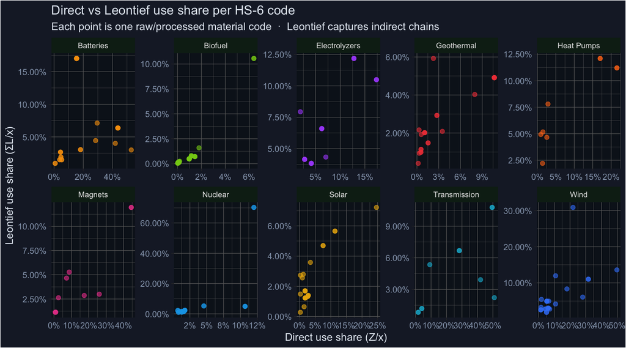

```r
gd_rp |>
  filter(leontief_use_share < 1, direct_use_share < 1) |>
  ggplot(aes(x=direct_use_share, y=leontief_use_share, colour=tech)) +
  geom_point(alpha=0.6, size=1.8) +
  scale_colour_manual(values=TECH_COLORS) +
  scale_x_continuous(labels=percent_format(accuracy=1)) +
  scale_y_continuous(labels=percent_format(accuracy=0.01)) +
  facet_wrap(~tech, ncol=5, scales="free") +
  labs(title="Direct vs Leontief use share per HS-6 code",
       subtitle="Each point is one raw/processed material code  ·  Leontief captures indirect chains",
       x="Direct use share (Z/x)", y="Leontief use share (ΣL/x)") +
  theme_dark() +
  theme(legend.position="none", strip.text=element_text(size=8),
        plot.background=element_rect(fill="#1a2030"),
        panel.background=element_rect(fill="#0d1520"),
        text=element_text(colour="#e2e8f0"),
        axis.text=element_text(colour="#94a3b8"),
        strip.background=element_rect(fill="#0f2518"))
```

## 7.6 Economic Interpretation

**Direct use share** (orange in summary table) measures what fraction of a material’s global output flows directly into clean technology manufacturing. It ranges from near-zero for bulk commodities (iron ore goes mainly to steel for construction) to 30–50% for specialised intermediates (lithium battery compounds, REE processing).

**Leontief use share** (blue) captures the full upstream chain — all indirect requirements induced by one unit of clean-tech final demand. It is smaller in magnitude than the direct share for most materials because the denominator ($x_j$) counts all global output of sector $j$, while clean-tech final demand per unit is modest relative to total global demand. This metric is more appropriate for materials several steps upstream of clean tech (e.g. iron ore → steel → turbine blade → wind electricity).

The **direct share is generally larger** because it captures concentrated, bilateral supply transactions. The **Leontief share is more conservative** and reflects the full economic footprint.

# 8 Limitations and Open Questions

# 9 Files and Reproducibility

| File | Description |
| --- | --- |
| `scripts/build_data/10a_parse_exiobase.py` | Extract A.txt + x.txt from EXIOBASE zip |
| `scripts/build_data/10_build_io_use_shares.R` | Z-based aggregation, Leontief + direct share computation |
| `data/exiobase/hs_exiobase_concordance.csv` | Per-HS6 concordance with both share metrics |
| `data/exiobase/io_use_shares.parquet` | Machine-readable shares (`product_code`, `tech`, `leontief_use_share`, `direct_use_share`) |
| `data/green_dict/green_dictionary.csv` | Green Dictionary + `exiobase_product` + `leontief_use_share` + `direct_use_share` |

To reproduce:

```bash
# Step 1: extract A.txt + x.txt from EXIOBASE zip (requires IOT_2019_pxp.zip)
python3 scripts/build_data/10a_parse_exiobase.py 2019

# Step 2: compute use shares
IO_MODE=real IO_YEAR=2019 Rscript scripts/build_data/10_build_io_use_shares.R

# Step 3: render this report
quarto render qmd/report/hs_exiobase_use_shares_methodology.qmd
```

EXIOBASE data is available at exiobase.eu (registration required). The `IOT_2019_pxp.zip` (~500 MB) goes in `data/exiobase/`.

# 10 References